# HW1_clustering

```python
import pandas as pd
```

```python
data = pd.read_csv("wine.data", header=None)
```

```python
data
```

|  | 0 | 1 | 2 | 3 | 4 | 5 | 6 | 7 | 8 | 9 | 10 | 11 | 12 | 13 |
| --- | --- | --- | --- | --- | --- | --- | --- | --- | --- | --- | --- | --- | --- | --- |
| 0 | 1 | 14.23 | 1.71 | 2.43 | 15.6 | 127 | 2.80 | 3.06 | 0.28 | 2.29 | 5.64 | 1.04 | 3.92 | 1065 |
| 1 | 1 | 13.20 | 1.78 | 2.14 | 11.2 | 100 | 2.65 | 2.76 | 0.26 | 1.28 | 4.38 | 1.05 | 3.40 | 1050 |
| 2 | 1 | 13.16 | 2.36 | 2.67 | 18.6 | 101 | 2.80 | 3.24 | 0.30 | 2.81 | 5.68 | 1.03 | 3.17 | 1185 |
| 3 | 1 | 14.37 | 1.95 | 2.50 | 16.8 | 113 | 3.85 | 3.49 | 0.24 | 2.18 | 7.80 | 0.86 | 3.45 | 1480 |
| 4 | 1 | 13.24 | 2.59 | 2.87 | 21.0 | 118 | 2.80 | 2.69 | 0.39 | 1.82 | 4.32 | 1.04 | 2.93 | 735 |
| ... | ... | ... | ... | ... | ... | ... | ... | ... | ... | ... | ... | ... | ... | ... |
| 173 | 3 | 13.71 | 5.65 | 2.45 | 20.5 | 95 | 1.68 | 0.61 | 0.52 | 1.06 | 7.70 | 0.64 | 1.74 | 740 |
| 174 | 3 | 13.40 | 3.91 | 2.48 | 23.0 | 102 | 1.80 | 0.75 | 0.43 | 1.41 | 7.30 | 0.70 | 1.56 | 750 |
| 175 | 3 | 13.27 | 4.28 | 2.26 | 20.0 | 120 | 1.59 | 0.69 | 0.43 | 1.35 | 10.20 | 0.59 | 1.56 | 835 |
| 176 | 3 | 13.17 | 2.59 | 2.37 | 20.0 | 120 | 1.65 | 0.68 | 0.53 | 1.46 | 9.30 | 0.60 | 1.62 | 840 |
| 177 | 3 | 14.13 | 4.10 | 2.74 | 24.5 | 96 | 2.05 | 0.76 | 0.56 | 1.35 | 9.20 | 0.61 | 1.60 | 560 |

178 rows × 14 columns

```python
# 幫它加上 column name
data.columns =['Class', 'Alcohol', 'Malic acid', 'Ash', 'Alcalinity of ash', 'Magnesium', 'Total phenols', 'Flavanoids', 'Nonflavanoid phenols', 'Proanthocyanins', 'Color intensity', 'Hue', 'OD280/OD315 of diluted wines', 'Proline']
```

```python
data
```

|  | Class | Alcohol | Malic acid | Ash | Alcalinity of ash | Magnesium | Total phenols | Flavanoids | Nonflavanoid phenols | Proanthocyanins | Color intensity | Hue | OD280/OD315 of diluted wines | Proline |
| --- | --- | --- | --- | --- | --- | --- | --- | --- | --- | --- | --- | --- | --- | --- |
| 0 | 1 | 14.23 | 1.71 | 2.43 | 15.6 | 127 | 2.80 | 3.06 | 0.28 | 2.29 | 5.64 | 1.04 | 3.92 | 1065 |
| 1 | 1 | 13.20 | 1.78 | 2.14 | 11.2 | 100 | 2.65 | 2.76 | 0.26 | 1.28 | 4.38 | 1.05 | 3.40 | 1050 |
| 2 | 1 | 13.16 | 2.36 | 2.67 | 18.6 | 101 | 2.80 | 3.24 | 0.30 | 2.81 | 5.68 | 1.03 | 3.17 | 1185 |
| 3 | 1 | 14.37 | 1.95 | 2.50 | 16.8 | 113 | 3.85 | 3.49 | 0.24 | 2.18 | 7.80 | 0.86 | 3.45 | 1480 |
| 4 | 1 | 13.24 | 2.59 | 2.87 | 21.0 | 118 | 2.80 | 2.69 | 0.39 | 1.82 | 4.32 | 1.04 | 2.93 | 735 |
| ... | ... | ... | ... | ... | ... | ... | ... | ... | ... | ... | ... | ... | ... | ... |
| 173 | 3 | 13.71 | 5.65 | 2.45 | 20.5 | 95 | 1.68 | 0.61 | 0.52 | 1.06 | 7.70 | 0.64 | 1.74 | 740 |
| 174 | 3 | 13.40 | 3.91 | 2.48 | 23.0 | 102 | 1.80 | 0.75 | 0.43 | 1.41 | 7.30 | 0.70 | 1.56 | 750 |
| 175 | 3 | 13.27 | 4.28 | 2.26 | 20.0 | 120 | 1.59 | 0.69 | 0.43 | 1.35 | 10.20 | 0.59 | 1.56 | 835 |
| 176 | 3 | 13.17 | 2.59 | 2.37 | 20.0 | 120 | 1.65 | 0.68 | 0.53 | 1.46 | 9.30 | 0.60 | 1.62 | 840 |
| 177 | 3 | 14.13 | 4.10 | 2.74 | 24.5 | 96 | 2.05 | 0.76 | 0.56 | 1.35 | 9.20 | 0.61 | 1.60 | 560 |

178 rows × 14 columns

## Partitional clustering

```python
# K-means (sklearn.cluster.KMeans)

from sklearn import cluster
import matplotlib.pyplot as plt
%matplotlib inline

X = data.iloc[0:178,1:14]
y = pd.DataFrame(data['Class'])

def KmeansPlot(X,y,title,px_idx=0,py_idx=1):
  plt.figure(figsize=(3, 3))
  plt.scatter(X.iloc[:, px_idx], X.iloc[:, py_idx], c=y)
  plt.title(title, fontsize=16, color="grey")

  km2 = cluster.KMeans(n_clusters=2).fit(X)
  km3 = cluster.KMeans(n_clusters=3).fit(X)
  km4 = cluster.KMeans(n_clusters=4).fit(X)

  plt.figure(figsize=(9, 3))
  plt.subplot(131)
  plt.scatter(X.iloc[:, px_idx], X.iloc[:, py_idx], c=km2.labels_)
  plt.title("K=2, J=%.2f" % km2.inertia_)
  #inertia_:sum of squared distances of samples to their closest cluster center

  plt.subplot(132)
  plt.scatter(X.iloc[:, px_idx], X.iloc[:, py_idx], c=km3.labels_)
  plt.title("K=3, J=%.2f" % km3.inertia_)

  plt.subplot(133)
  plt.scatter(X.iloc[:, px_idx], X.iloc[:, py_idx], c=km4.labels_)
  plt.title("K=4, J=%.2f" % km4.inertia_)
```

```python
X
```

|  | Alcohol | Malic acid | Ash | Alcalinity of ash | Magnesium | Total phenols | Flavanoids | Nonflavanoid phenols | Proanthocyanins | Color intensity | Hue | OD280/OD315 of diluted wines | Proline |
| --- | --- | --- | --- | --- | --- | --- | --- | --- | --- | --- | --- | --- | --- |
| 0 | 14.23 | 1.71 | 2.43 | 15.6 | 127 | 2.80 | 3.06 | 0.28 | 2.29 | 5.64 | 1.04 | 3.92 | 1065 |
| 1 | 13.20 | 1.78 | 2.14 | 11.2 | 100 | 2.65 | 2.76 | 0.26 | 1.28 | 4.38 | 1.05 | 3.40 | 1050 |
| 2 | 13.16 | 2.36 | 2.67 | 18.6 | 101 | 2.80 | 3.24 | 0.30 | 2.81 | 5.68 | 1.03 | 3.17 | 1185 |
| 3 | 14.37 | 1.95 | 2.50 | 16.8 | 113 | 3.85 | 3.49 | 0.24 | 2.18 | 7.80 | 0.86 | 3.45 | 1480 |
| 4 | 13.24 | 2.59 | 2.87 | 21.0 | 118 | 2.80 | 2.69 | 0.39 | 1.82 | 4.32 | 1.04 | 2.93 | 735 |
| ... | ... | ... | ... | ... | ... | ... | ... | ... | ... | ... | ... | ... | ... |
| 173 | 13.71 | 5.65 | 2.45 | 20.5 | 95 | 1.68 | 0.61 | 0.52 | 1.06 | 7.70 | 0.64 | 1.74 | 740 |
| 174 | 13.40 | 3.91 | 2.48 | 23.0 | 102 | 1.80 | 0.75 | 0.43 | 1.41 | 7.30 | 0.70 | 1.56 | 750 |
| 175 | 13.27 | 4.28 | 2.26 | 20.0 | 120 | 1.59 | 0.69 | 0.43 | 1.35 | 10.20 | 0.59 | 1.56 | 835 |
| 176 | 13.17 | 2.59 | 2.37 | 20.0 | 120 | 1.65 | 0.68 | 0.53 | 1.46 | 9.30 | 0.60 | 1.62 | 840 |
| 177 | 14.13 | 4.10 | 2.74 | 24.5 | 96 | 2.05 | 0.76 | 0.56 | 1.35 | 9.20 | 0.61 | 1.60 | 560 |

178 rows × 13 columns

```python
y
```

|  | Class |
| --- | --- |
| 0 | 1 |
| 1 | 1 |
| 2 | 1 |
| 3 | 1 |
| 4 | 1 |
| ... | ... |
| 173 | 3 |
| 174 | 3 |
| 175 | 3 |
| 176 | 3 |
| 177 | 3 |

178 rows × 1 columns

### 1. 比較使用原始資料所有features，和只使用 alcohol與malic acid的分群結果

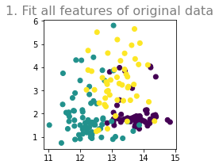

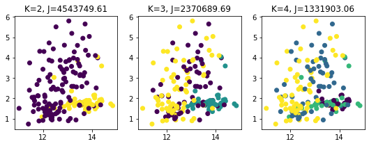

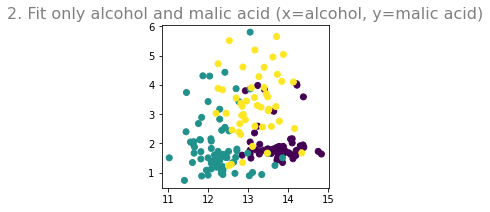

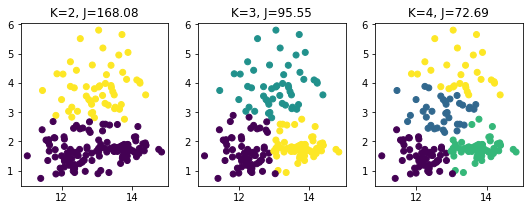

```python
# Fit all features of original data
KmeansPlot(X,y['Class'],'1. Fit all features of original data')
# Fit only alcohol and malic acid
X_2 = X.iloc[:,:2]
KmeansPlot(X_2,y['Class'],'2. Fit only alcohol and malic acid (x=alcohol, y=malic acid)')
```

##### J代表inertia，inertia的算法為樣本點到最近的群中心的距離平方和，所以分越多群 J值就越小。

### 2. 比較使用原始資料，和使用標準化後的原始資料的分群結果。

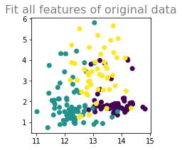

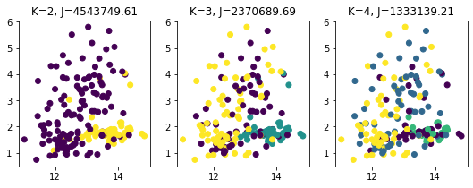

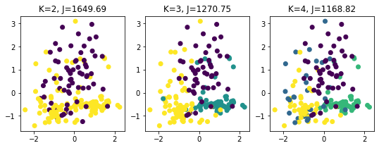

```python
# Fit all features of original data
KmeansPlot(X,y['Class'],'Fit all features of original data')
# Fit all features of normalized data
X_normal = (X-X.mean())/X.std()
KmeansPlot(X_normal,y['Class'],'Fit all features of normalized data')
```

##### 看起來使用標準化後的資料並分成三群的結果，和資料原來的分群非常相似，只有少數幾個點不一樣。

##### 進行標準化處理，是為了避免每個 feature因為單位不同，導致在距離的計算上失真。

### 該如何決定分群的最佳數目?

#### 可以利用 Elbow Method 或 Average Silhouette Method

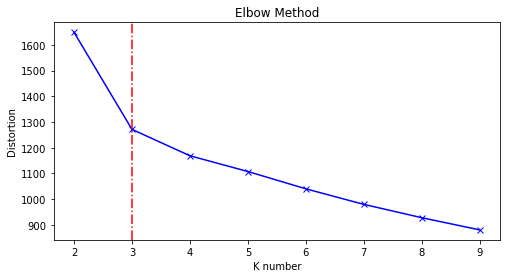

```python
# K-Means Elbow Method
distortions = []
for k in range(2,10):
  kmeanModel = cluster.KMeans(n_clusters=k).fit(X_normal)
  distortions.append(kmeanModel.inertia_)

plt.figure(figsize=(8,4))
plt.plot(range(2,10), distortions, 'bx-')
plt.axvline(x=3, c='r', ls='-.')
plt.xlabel('K number')
plt.ylabel('Distortion')
plt.title('Elbow Method')
```

##### 從 Elbow Method的結果可以看出，位於轉折處的 K number為 3，所以 Elbow Method 認為分成 3群最合適。

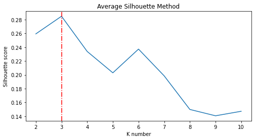

```python
# K-Means Average Silhouette Method
from sklearn.metrics import silhouette_score

silhouette_avg = []
for k in range(2,11):
  kmeanModel = cluster.KMeans(n_clusters=k).fit(X_normal)
  silhouette_avg.append(silhouette_score(X_normal, kmeanModel.labels_))

plt.figure(figsize=(8,4))
plt.plot(range(2,11), silhouette_avg)
plt.axvline(x=3, c='r', ls='-.')
plt.xlabel('K number')
plt.ylabel('Silhouette score')
plt.title('Average Silhouette Method')
```

##### 從 Average Silhouette Method的結果可以看出，擁有最高分的Silhouette score的 K number為 3，所以 Average Silhouette Method 也是認為分成 3群最合適。

### 3. 比較K-means 與 K-Medoids的分群效果

##### K-medoids的中心點為實際的樣本點。

```python
# pip install scikit-learn-extra
```

```
  Using cached scikit_learn_extra-0.2.0-cp38-cp38-win_amd64.whl (381 kB)
```

```python
from sklearn_extra.cluster import KMedoids
```

```python
KMed = KMedoids(n_clusters=3,init='random',random_state=5)
KMed.fit(X_normal)
KMed.predict(X_normal)
```

```
array([0, 0, 0, 0, 0, 0, 0, 0, 0, 0, 0, 0, 0, 0, 0, 0, 0, 0, 0, 0, 0, 0,
       0, 0, 0, 0, 0, 0, 0, 0, 0, 0, 0, 0, 0, 0, 0, 0, 0, 0, 0, 0, 0, 0,
       0, 0, 0, 0, 0, 0, 0, 0, 0, 0, 0, 0, 0, 0, 0, 1, 1, 1, 1, 0, 1, 0,
       1, 1, 1, 0, 1, 0, 1, 0, 0, 1, 1, 1, 1, 0, 1, 1, 1, 2, 1, 1, 1, 1,
       1, 1, 1, 1, 1, 1, 1, 0, 2, 1, 0, 1, 1, 1, 1, 1, 1, 1, 1, 1, 1, 0,
       0, 1, 1, 1, 1, 1, 1, 1, 1, 1, 0, 0, 2, 1, 0, 1, 1, 1, 1, 1, 2, 2,
       2, 2, 2, 2, 2, 2, 2, 2, 2, 2, 2, 2, 2, 2, 2, 2, 2, 2, 2, 2, 2, 2,
       2, 2, 2, 2, 2, 2, 2, 2, 2, 2, 2, 2, 2, 2, 2, 2, 2, 2, 2, 2, 2, 2,
       2, 2], dtype=int64)
```

```python
def KmedoidsPlot(X,y,title,px_idx=0,py_idx=1):
  plt.figure(figsize=(3, 3))
  plt.scatter(X.iloc[:, px_idx], X.iloc[:, py_idx], c=y)
  plt.title(title, fontsize=16, color="grey")

  km3 = cluster.KMeans(n_clusters=3).fit(X)
  kmd3 = KMedoids(n_clusters=3).fit(X)

  plt.figure(figsize=(6, 3))

  plt.subplot(121)
  plt.scatter(X.iloc[:, px_idx], X.iloc[:, py_idx], c=km3.labels_)
  plt.title("Kmeans, K=3, J=%.2f" % km3.inertia_)

  plt.subplot(122)
  plt.scatter(X.iloc[:, px_idx], X.iloc[:, py_idx], c=kmd3.labels_)
  plt.title("Kmedoids, K=3, J=%.2f" % kmd3.inertia_)
```

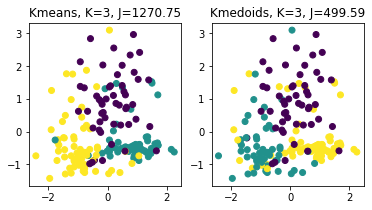

```python
KmedoidsPlot(X_normal,y['Class'],'Fit all features of normalized data')
```

##### 在這筆資料裡，看起來使用K-means的分群結果會比較接近真實的樣子。

### 4. 比較K-means和Fuzzy c-means的分群效果

##### Fuzzy c-means多考慮了樣本點隸屬於各個群中心的機率

```python
# pip install --user fuzzy_c_means
```

```python
from fcmeans import FCM
```

```python
Fuzzy_c = FCM(n_clusters=3)
Fuzzy_c.fit(X_normal.to_numpy())
Fuzzy_c.predict(X_normal.to_numpy())
```

```
array([0, 0, 0, 0, 0, 0, 0, 0, 0, 0, 0, 0, 0, 0, 0, 0, 0, 0, 0, 0, 0, 0,
       0, 0, 0, 0, 0, 0, 0, 0, 0, 0, 0, 0, 0, 0, 0, 0, 0, 0, 0, 0, 0, 0,
       0, 0, 0, 0, 0, 0, 0, 0, 0, 0, 0, 0, 0, 0, 0, 1, 1, 2, 1, 1, 1, 1,
       1, 1, 1, 1, 1, 1, 1, 0, 1, 1, 1, 1, 1, 1, 1, 1, 1, 2, 1, 1, 1, 1,
       1, 1, 1, 1, 1, 1, 1, 0, 1, 1, 1, 1, 1, 1, 1, 1, 1, 1, 1, 1, 1, 1,
       1, 1, 1, 1, 1, 1, 1, 1, 2, 1, 1, 0, 1, 1, 1, 1, 1, 1, 1, 1, 2, 2,
       2, 2, 2, 2, 2, 2, 2, 2, 2, 2, 2, 2, 2, 2, 2, 2, 2, 2, 2, 2, 2, 2,
       2, 2, 2, 2, 2, 2, 2, 2, 2, 2, 2, 2, 2, 2, 2, 2, 2, 2, 2, 2, 2, 2,
       2, 2], dtype=int64)
```

```python
def FuzzycPlot(X,y,title,px_idx=0,py_idx=1):
  plt.figure(figsize=(3, 3))
  plt.scatter(X.iloc[:, px_idx], X.iloc[:, py_idx], c=y)
  plt.title(title, fontsize=16, color="grey")

  km3 = cluster.KMeans(n_clusters=3).fit(X)

  Fuzzy_c = FCM(n_clusters=3)
  Fuzzy_c.fit(X_normal.to_numpy())
  kmd3 = Fuzzy_c.predict(X_normal.to_numpy())

  plt.figure(figsize=(6, 3))

  plt.subplot(121)
  plt.scatter(X.iloc[:, px_idx], X.iloc[:, py_idx], c=km3.labels_)
  plt.title("Kmeans, K=3")

  plt.subplot(122)
  plt.scatter(X.iloc[:, px_idx], X.iloc[:, py_idx], c=kmd3)
  plt.title("Fuzzy-c, K=3")
```

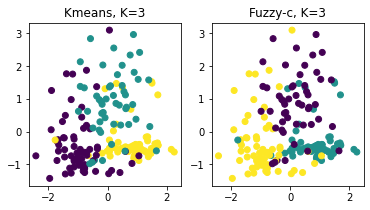

```python
FuzzycPlot(X_normal,y['Class'],'Fit all features of normalized data')
```

##### 看起來使用K-means和Fuzzy c-means的分群效果都很優秀，只有少數幾個點和真實值不一樣。

## Hierarchical clustering

##### linkage method: 'single' (最近距離)，'complete' (最遠距離), 'average'(平均距離), 'centroid' (中心點距離), 'ward' (群內變異最小)

```python
# Hierarchical clustering: bottom-up
from scipy.cluster.hierarchy import dendrogram,linkage,fcluster

A = linkage(X_normal, 'single') #construct linkage matrix
B = linkage(X_normal, 'complete')
C = linkage(X_normal, 'average')
D = linkage(X_normal, 'centroid')
E = linkage(X_normal, 'ward')

A_clu = fcluster(A,t=3,criterion='maxclust') #assign max cluster number
print(A_clu)
B_clu = fcluster(B,t=3,criterion='maxclust')
print(B_clu)
C_clu = fcluster(C,t=3,criterion='maxclust')
print(C_clu)
D_clu = fcluster(D,t=3,criterion='maxclust')
print(D_clu)
E_clu = fcluster(E,t=3,criterion='maxclust')
print(E_clu)
```

```
[2 2 2 2 2 2 2 2 2 2 2 2 2 2 2 2 2 2 2 2 2 2 2 2 2 2 2 2 2 2 2 2 2 2 2 2 2
 2 2 2 2 2 2 2 2 2 2 2 2 2 2 2 2 2 2 2 2 2 2 2 2 2 2 2 2 2 2 2 2 1 2 2 2 3
 2 2 2 2 1 2 2 2 2 2 2 2 2 2 2 2 2 2 2 2 2 1 2 2 2 2 2 2 2 2 2 2 2 2 2 2 2
 2 2 2 2 2 2 2 2 2 2 2 2 2 2 2 2 2 2 2 2 2 2 2 2 2 2 2 2 2 2 2 2 2 2 2 2 2
 2 2 2 2 2 2 2 2 2 2 2 2 2 2 2 2 2 2 2 2 2 2 2 2 2 2 2 2 2 2]
[1 1 1 1 3 1 1 1 1 1 1 1 1 1 1 3 3 3 1 1 1 1 1 1 1 3 1 1 3 1 1 1 1 3 1 1 1
 1 1 1 1 1 1 1 1 1 1 1 1 1 1 1 1 3 1 1 1 1 1 1 1 1 1 3 1 1 1 3 1 1 1 3 3 3
 3 1 1 1 1 3 3 3 3 2 3 3 1 3 3 3 3 3 3 3 3 1 2 3 3 3 1 3 3 3 3 3 3 3 3 3 1
 3 3 3 3 3 3 3 2 3 3 3 3 3 3 3 3 3 3 3 2 2 2 2 2 2 2 2 2 2 2 2 2 2 2 2 2 2
 2 2 2 2 2 2 2 2 2 2 2 2 2 2 2 2 2 2 2 2 2 2 2 2 2 2 2 2 2 2]
[2 2 2 2 2 2 2 2 2 2 2 2 2 2 2 2 2 2 2 2 2 2 2 2 2 1 2 2 2 2 2 2 2 2 2 2 2
 2 2 2 2 2 2 2 2 2 2 2 2 2 2 2 2 2 2 2 2 2 2 3 2 2 2 2 2 2 2 2 2 2 2 2 2 1
 2 2 2 2 2 2 2 2 2 2 2 2 2 2 2 2 2 2 2 2 2 2 2 2 2 2 2 2 2 2 2 2 2 2 2 2 2
 2 2 2 2 2 2 2 2 2 2 1 2 2 2 2 2 2 2 2 2 2 2 2 2 2 2 2 2 2 2 2 2 2 2 2 2 2
 2 2 2 2 2 2 2 2 2 2 2 2 2 2 2 2 2 2 2 2 2 2 2 2 2 2 2 2 2 2]
[2 2 2 2 2 2 2 2 2 2 2 2 2 2 2 2 2 2 2 2 2 2 2 2 2 2 2 2 2 2 2 2 2 2 2 2 2
 2 2 2 2 2 2 2 2 2 2 2 2 2 2 2 2 2 2 2 2 2 2 3 2 2 2 2 2 2 2 2 2 1 2 2 2 2
 2 2 2 2 1 2 2 2 2 2 2 2 2 2 2 2 2 2 2 2 2 1 2 2 2 2 2 2 2 2 2 2 2 2 2 2 2
 2 2 2 2 2 2 2 2 2 2 2 2 2 2 2 2 2 2 2 2 2 2 2 2 2 2 2 2 2 2 2 2 2 2 2 2 2
 2 2 2 2 2 2 2 2 2 2 2 2 2 2 2 2 2 2 2 2 2 2 2 2 2 2 2 2 2 2]
[2 2 2 2 2 2 2 2 2 2 2 2 2 2 2 2 2 2 2 2 2 2 2 2 2 2 2 2 2 2 2 2 2 2 2 2 2
 2 2 2 2 2 2 2 2 2 2 2 2 2 2 2 2 2 2 2 2 2 2 3 1 1 3 3 3 2 2 3 1 3 1 2 3 2
 3 3 3 1 3 3 3 3 3 1 3 3 3 3 3 3 3 3 3 3 3 3 1 3 3 3 3 3 3 3 3 3 3 3 3 3 3
 3 3 3 3 3 3 3 1 3 3 2 3 3 3 3 3 3 3 3 1 1 1 1 1 1 1 1 1 1 1 1 1 1 1 1 1 1
 1 1 1 1 1 1 1 1 1 1 1 1 1 1 1 1 1 1 1 1 1 1 1 1 1 1 1 1 1 1]
```

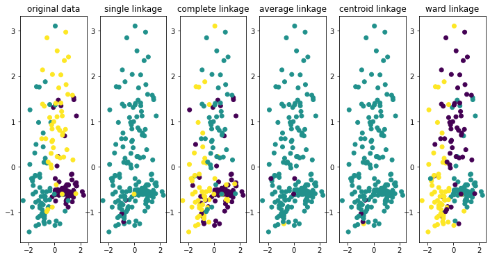

```python
plt.figure(figsize=(12, 6))
plt.subplot(161)
plt.scatter(X_normal.iloc[:, 0], X_normal.iloc[:, 1], c=y['Class'])
plt.title("original data")

plt.subplot(162)
plt.scatter(X_normal.iloc[:, 0], X_normal.iloc[:, 1], c=A_clu)
plt.title("single linkage")

plt.subplot(163)
plt.scatter(X_normal.iloc[:, 0], X_normal.iloc[:, 1], c=B_clu)
plt.title("complete linkage")

plt.subplot(164)
plt.scatter(X_normal.iloc[:, 0], X_normal.iloc[:, 1], c=C_clu)
plt.title("average linkage")

plt.subplot(165)
plt.scatter(X_normal.iloc[:, 0], X_normal.iloc[:, 1], c=D_clu)
plt.title("centroid linkage")

plt.subplot(166)
plt.scatter(X_normal.iloc[:, 0], X_normal.iloc[:, 1], c=E_clu)
plt.title("ward linkage")
```

##### 看起來使用 ward linkage的結果，會和資料原來的分群非常相似。

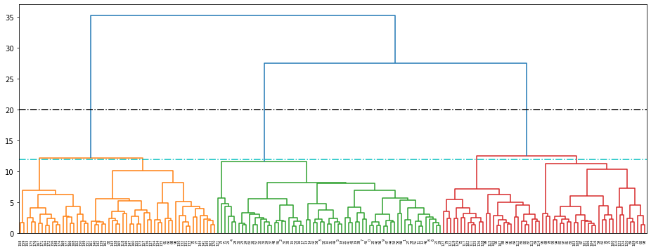

```python
fig = plt.figure(figsize=(16, 6))
dn = dendrogram(E)
plt.axhline(y=20, c='k', ls='-.')
plt.axhline(y=12, c='c', ls='-.')
```

##### 將以 ward linkage分群的結果繪製成 dendrogram。距離20以內可以區分為3群，距離12以內可以區分為5群。

##### Partitional Clustering : 需指定分群數目，只能分成大群，但執行速度很快。

##### Hierarchical Clustering : 不需指定分群數目，可以分得較細，但較費時。

### 利用SOM進行分群

```python
# pip install minisom
```

```python
from minisom import MiniSom
```

```python
som = MiniSom(10, 10, 13, sigma=0.3, learning_rate=0.5) # initialization of 10x10 SOM
```

```python
som.train(X_normal.to_numpy(), 10000)
```

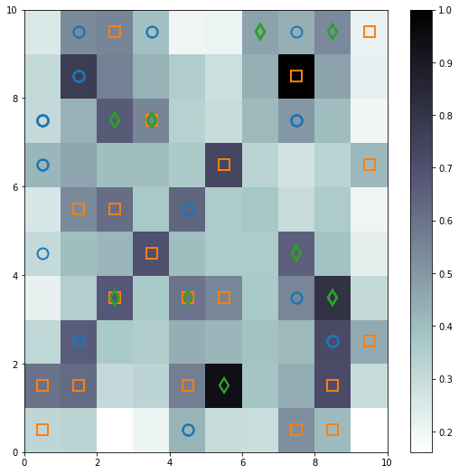

```python
import numpy as np
plt.figure(figsize=(9, 9))

plt.pcolor(som.distance_map().T, cmap='bone_r')  # plotting the distance map as background
plt.colorbar()

# different colors and markers for each label
markers = ['o', 's', 'd']
colors = ['C0', 'C1', 'C2']
for cnt, xx in enumerate(X_normal.to_numpy()):
    w = som.winner(xx)  # getting the winner
    # palce a marker on the winning position for the sample xx
    target = y['Class'].values
    plt.plot(w[0]+.5, w[1]+.5, markers[target[cnt]-1], markerfacecolor='None',
             markeredgecolor=colors[target[cnt]-1], markersize=12, markeredgewidth=2)

plt.show()
```

##### 看起來用som的分群效果好像沒有很好。